# full_report

## P01：金融数据获取

本 Notebook 完成数据获取任务：

1. 创建项目目录结构
2. 下载10只股票日行情（后复权）
3. 下载沪深300及创业板指
4. 下载CPI和M2宏观指标
5. 下载财务指标数据

### 1. 安装依赖库

```python
!pip install akshare baostock pandas statsmodels matplotlib seaborn pyarrow sqlalchemy -q
```

导入 akshare（数据获取）、pandas（数据处理）、statsmodels（回归分析）、matplotlib/seaborn（可视化）等库。安装后无需重复安装。

### 2. 创建项目目录结构

```python
import os

project_root = "dshw-p01"

directories = [
    project_root,
    f"{project_root}/data/stock",
    f"{project_root}/data/index",
    f"{project_root}/data/macro",
    f"{project_root}/data/finance",
    f"{project_root}/data/clean",
    f"{project_root}/data/combined",
    f"{project_root}/output",
]

for dir_path in directories:
    os.makedirs(dir_path, exist_ok=True)
    print(f"✓ {dir_path}")

print(f"\n共创建 {len(directories)} 个目录")
```

```
✓ dshw-p01
✓ dshw-p01/data/stock
✓ dshw-p01/data/index
✓ dshw-p01/data/macro
✓ dshw-p01/data/finance
✓ dshw-p01/data/clean
✓ dshw-p01/data/combined
✓ dshw-p01/output

共创建 8 个目录
```

### 3. 定义股票列表

```python
import pandas as pd

stock_list = [
    {"code": "000001", "name": "平安银行", "industry": "银行"},
    {"code": "600036", "name": "招商银行", "industry": "银行"},
    {"code": "600519", "name": "贵州茅台", "industry": "白酒"},
    {"code": "000858", "name": "五粮液", "industry": "白酒"},
    {"code": "600048", "name": "保利发展", "industry": "房地产"},
    {"code": "000002", "name": "万科A", "industry": "房地产"},
    {"code": "601857", "name": "中国石油", "industry": "能源"},
    {"code": "600900", "name": "长江电力", "industry": "能源"},
    {"code": "002594", "name": "比亚迪", "industry": "汽车"},
    {"code": "600050", "name": "中国联通", "industry": "通讯"},
]

stocks_df = pd.DataFrame(stock_list)
print("股票列表（共10只）")
print("=" * 50)
print(stocks_df.to_string(index=False))
print("\n行业分布：")
print(stocks_df["industry"].value_counts().to_string())
```

```
股票列表（共10只）
==================================================
  code name industry
000001 平安银行       银行
600036 招商银行       银行
600519 贵州茅台       白酒
000858  五粮液       白酒
600048 保利发展      房地产
000002  万科A      房地产
601857 中国石油       能源
600900 长江电力       能源
002594  比亚迪       汽车
600050 中国联通       通讯

行业分布：
industry
银行     2
白酒     2
房地产    2
能源     2
汽车     1
通讯     1
```

定义选股清单：10只股票覆盖6个行业，其中银行和白酒各2只（满足每个行业最多2只的要求），房地产、能源各2只，汽车、通讯各1只。列表以字典形式存储，每个元素包含股票代码、名称、行业，便于后续循环下载。

### 4. 定义下载日志函数

```python
from datetime import datetime
import time

def log_download(log_file, status, data_name, info=""):
    ts = datetime.now().strftime("%Y-%m-%d %H:%M:%S")
    line = f"[{ts}] {status:7s} {data_name:20s} {info}\n"
    with open(log_file, "a", encoding="utf-8") as f:
        f.write(line)
    print(line.strip())
```

定义 `log_download()` 函数，每次下载调用一次，自动记录时间戳（精确到秒）、状态（SUCCESS/FAILED）、数据名称和附加信息（如数据形状或错误原因）。日志文件存于项目根目录，便于后续检查哪些数据下载失败。

### 5. 下载股票日行情数据（后复权）

```python
import baostock as bs

# 登录 baostock
bs.login()

start_date = "20200101"
end_date = "20260403"
log_file = f"{project_root}/download_log.txt"

print("开始下载10只股票日行情（后复权）...")
print("=" * 50)

for stock in stock_list:
    code = stock["code"]
    name = stock["name"]

    # baostock 代码格式：sh.600519 或 sz.000001
    if code.startswith("0"):
        bs_code = f"sz.{code}"
    else:
        bs_code = f"sh.{code}"

    try:
        # 使用 baostock 获取后复权数据
        rs = bs.query_history_k_data_plus(
            bs_code,
            "date,open,high,low,close,volume,amount",
            start_date=f"{start_date[:4]}-{start_date[4:6]}-{start_date[6:]}",
            end_date=f"{end_date[:4]}-{end_date[4:6]}-{end_date[6:]}",
            frequency="d",
            adjustflag="2"   # 2=后复权
        )

        data_list = []
        while rs.next():
            data_list.append(rs.get_row_data())
        df = pd.DataFrame(data_list, columns=rs.fields)

        if len(df) == 0:
            raise Exception("No data returned")

        # 保存为 CSV
        out_path = f"{project_root}/data/stock/stock_{code}.csv"
        df.to_csv(out_path, index=False, encoding="utf-8-sig")

        log_download(log_file, "SUCCESS", f"stock_{code}", f"shape={df.shape}")

    except Exception as e:
        log_download(log_file, "FAILED", f"stock_{code}", f"Error: {e}")

    time.sleep(1)

# 登出 baostock
bs.logout()
print("股票行情下载完毕")
```

```
login success!
开始下载10只股票日行情（后复权）...
==================================================
[2026-04-04 21:23:33] SUCCESS stock_000001         shape=(1514, 7)
[2026-04-04 21:23:44] SUCCESS stock_600036         shape=(1514, 7)
[2026-04-04 21:23:59] SUCCESS stock_600519         shape=(1514, 7)
[2026-04-04 21:24:18] SUCCESS stock_000858         shape=(1514, 7)
[2026-04-04 21:24:28] SUCCESS stock_600048         shape=(1514, 7)
[2026-04-04 21:24:35] SUCCESS stock_000002         shape=(1514, 7)
[2026-04-04 21:24:52] SUCCESS stock_601857         shape=(1514, 7)
[2026-04-04 21:25:05] SUCCESS stock_600900         shape=(1514, 7)
[2026-04-04 21:25:13] SUCCESS stock_002594         shape=(1514, 7)
[2026-04-04 21:26:04] SUCCESS stock_600050         shape=(1514, 7)
logout success!
股票行情下载完毕
```

### 6. 下载市场指数数据

```python
print("开始下载市场指数...")
print("=" * 50)

bs.login()

# 沪深300
try:
    rs = bs.query_history_k_data_plus(
        "sh.000300",
        "date,open,high,low,close,volume,amount",
        start_date="2020-01-01",
        end_date="2026-04-03",
        frequency="d"
    )
    data_list = []
    while rs.next():
        data_list.append(rs.get_row_data())
    df = pd.DataFrame(data_list, columns=rs.fields)
    df.to_csv(f"{project_root}/data/index/index_000300.csv",
              index=False, encoding="utf-8-sig")
    log_download(log_file, "SUCCESS", "index_000300", f"shape={df.shape}")
    print(f"  沪深300: {df.shape}")
except Exception as e:
    log_download(log_file, "FAILED", "index_000300", f"Error: {e}")

# 创业板指
try:
    rs = bs.query_history_k_data_plus(
        "sz.399006",
        "date,open,high,low,close,volume,amount",
        start_date="2020-01-01",
        end_date="2026-04-03",
        frequency="d"
    )
    data_list = []
    while rs.next():
        data_list.append(rs.get_row_data())
    df = pd.DataFrame(data_list, columns=rs.fields)
    df.to_csv(f"{project_root}/data/index/index_399006.csv",
              index=False, encoding="utf-8-sig")
    log_download(log_file, "SUCCESS", "index_399006", f"shape={df.shape}")
    print(f"  创业板指: {df.shape}")
except Exception as e:
    log_download(log_file, "FAILED", "index_399006", f"Error: {e}")

bs.logout()
print("指数数据下载完毕")
```

```
开始下载市场指数...
==================================================
login success!
[2026-04-04 21:36:14] SUCCESS index_000300         shape=(1514, 7)
  沪深300: (1514, 7)
[2026-04-04 21:36:18] SUCCESS index_399006         shape=(1514, 7)
  创业板指: (1514, 7)
logout success!
指数数据下载完毕
```

下载沪深300（代码 sh000300）和创业板指（代码 sz399006）的日行情数据。沪深300是CAPM回归中必备的市场基准，代表A股大盘蓝筹；创业板指代表成长型股票，两者可比对不同市场板块的表现。数据同样限定在2020-01-01至2026-04-03时间范围内，保存至 `data/index/` 目录。

### 7. 下载宏观经济指标

```python
print("开始下载宏观经济指标...")
print("=" * 50)

try:
    cpi = ak.macro_china_cpi_yearly()
    print(f"  CPI 列名: {cpi.columns.tolist()}")
    print(cpi.head(3))
    cpi.to_csv(f"{project_root}/data/macro/macro_cpi.csv",
               index=False, encoding="utf-8-sig")
    log_download(log_file, "SUCCESS", "macro_cpi", f"shape={cpi.shape}")
except Exception as e:
    log_download(log_file, "FAILED", "macro_cpi", f"Error: {e}")

try:
    m2 = ak.macro_china_money_supply()
    print(f"  M2 列名: {m2.columns.tolist()}")
    print(m2.head(3))
    m2.to_csv(f"{project_root}/data/macro/macro_m2.csv",
              index=False, encoding="utf-8-sig")
    log_download(log_file, "SUCCESS", "macro_m2", f"shape={m2.shape}")
except Exception as e:
    log_download(log_file, "FAILED", "macro_m2", f"Error: {e}")

print("宏观数据下载完毕")
```

```
开始下载宏观经济指标...
==================================================
  CPI 列名: ['商品', '日期', '今值', '预测值', '前值']
          商品          日期   今值  预测值   前值
0  中国CPI年率报告  1986-02-01  7.1  NaN  NaN
1  中国CPI年率报告  1986-03-01  7.1  NaN  7.1
2  中国CPI年率报告  1986-04-01  7.1  NaN  7.1
[2026-04-04 21:47:45] SUCCESS macro_cpi            shape=(477, 5)
  M2 列名: ['月份', '货币和准货币(M2)-数量(亿元)', '货币和准货币(M2)-同比增长', '货币和准货币(M2)-环比增长', '货币(M1)-数量(亿元)', '货币(M1)-同比增长', '货币(M1)-环比增长', '流通中的现金(M0)-数量(亿元)', '流通中的现金(M0)-同比增长', '流通中的现金(M0)-环比增长']
          月份  货币和准货币(M2)-数量(亿元)  货币和准货币(M2)-同比增长  货币和准货币(M2)-环比增长  \
0  2026年02月份         3492159.91              9.0         0.584687
1  2026年01月份         3471860.39              9.0         2.025077
2  2025年12月份         3402948.06              8.5         0.980968

   货币(M1)-数量(亿元)  货币(M1)-同比增长  货币(M1)-环比增长  流通中的现金(M0)-数量(亿元)  \
0     1159258.82          5.9    -1.731121          151436.41
1     1179680.52          4.9     2.123888          146138.60
2     1155146.50          3.8     2.327986          141261.37

   流通中的现金(M0)-同比增长  流通中的现金(M0)-环比增长
0             14.1         3.625196
1              2.7         3.452628
2             10.2         2.833230
[2026-04-04 21:47:45] SUCCESS macro_m2             shape=(218, 10)
宏观数据下载完毕
```

下载两项月度宏观指标：CPI同比增速（必选，反映通胀水平）和M2同比增速（自选，反映货币政策松紧）。CPI与货币政策预期密切相关——通胀上行可能触发紧缩预期，导致股市回调；M2增速反映市场流动性充裕程度，流动性充裕时往往利好股市。宏观数据为月度频率，后续与日频股票数据合并时需做频率对齐。

### 8. 下载财务指标数据（长格式）

```python
print("开始下载财务指标...")
print("=" * 50)

bs.login()
finance_records = []

for stock in stock_list:
    code = stock["code"]
    name = stock["name"]

    # baostock 代码格式
    if code.startswith("0"):
        bs_code = f"sz.{code}"
    else:
        bs_code = f"sh.{code}"

    for year in range(2020, 2026):
        for quarter in [1, 2, 3, 4]:
            try:
                rs = bs.query_profit_data(
                    code=bs_code,
                    year=str(year),
                    quarter=str(quarter)
                )

                while rs.next():
                    row = rs.get_row_data()
                    if row and len(row) > 2:
                        for j, val in enumerate(row):
                            if val and val != "" and val != "--" and j > 2:
                                col_name = rs.fields[j]
                                try:
                                    finance_records.append({
                                        "code": code,
                                        "name": name,
                                        "year": year,
                                        "quarter": quarter,
                                        "indicator": col_name,
                                        "value": float(val)
                                    })
                                except:
                                    pass
                break
            except:
                pass

    stock_records = [r for r in finance_records if r["code"] == code]
    print(f"  {name}({code}): {len(stock_records)} 条财务记录")
    log_download(log_file, "SUCCESS", f"finance_{code}", f"records={len(stock_records)}")
    time.sleep(0.5)

bs.logout()

if finance_records:
    fin_df = pd.DataFrame(finance_records)
    fin_df.to_csv(f"{project_root}/data/finance/finance_ratios.csv",
                  index=False, encoding="utf-8-sig")
    print(f"财务数据保存完成：{len(fin_df)} 条记录，{fin_df['indicator'].nunique()} 个指标")
else:
    print("未获取到有效财务数据")
```

```
开始下载财务指标...
==================================================
login success!
  平安银行(000001): 36 条财务记录
[2026-04-04 21:47:59] SUCCESS finance_000001       records=36
  招商银行(600036): 36 条财务记录
[2026-04-04 21:48:03] SUCCESS finance_600036       records=36
  贵州茅台(600519): 42 条财务记录
[2026-04-04 21:48:05] SUCCESS finance_600519       records=42
  五粮液(000858): 42 条财务记录
[2026-04-04 21:48:16] SUCCESS finance_000858       records=42
  保利发展(600048): 42 条财务记录
[2026-04-04 21:48:25] SUCCESS finance_600048       records=42
  万科A(000002): 42 条财务记录
[2026-04-04 21:48:28] SUCCESS finance_000002       records=42
  中国石油(601857): 42 条财务记录
[2026-04-04 21:48:39] SUCCESS finance_601857       records=42
  长江电力(600900): 42 条财务记录
[2026-04-04 21:48:56] SUCCESS finance_600900       records=42
  比亚迪(002594): 42 条财务记录
[2026-04-04 21:49:02] SUCCESS finance_002594       records=42
  中国联通(600050): 42 条财务记录
[2026-04-04 21:49:25] SUCCESS finance_600050       records=42
logout success!
财务数据保存完成：408 条记录，7 个指标
```

### 9. 查看下载日志

```python
print("=" * 50)
print("下载日志内容")
print("=" * 50)

with open(log_file, "r", encoding="utf-8") as f:
    content = f.read()
    print(content)

success_count = content.count("SUCCESS")
failed_count = content.count("FAILED")
print(f"\n汇总：SUCCESS {success_count} | FAILED {failed_count}")
```

[output not shown]

读取 `download_log.txt` 完整内容。日志格式为 `[时间戳] SUCCESS/FAILED 数据名称 shape或错误信息`。统计 SUCCESS 和 FAILED 次数可快速判断数据完整性。若有失败项，需在后续清洗阶段处理（更换数据源或剔除）。

### 10. 本 Notebook 完成情况

| 任务 | 状态 |
| --- | --- |
| 创建目录结构 | checked |
| 下载10只股票日行情（后复权） | checked |
| 下载沪深300、创业板指 | checked |
| 下载CPI、M2宏观指标 | checked |
| 下载财务指标（长格式） | checked |
| 下载日志记录 | checked |

下一步：运行 `02_clean.ipynb` 进行数据清洗。

## P02：数据清洗与存储

本 Notebook 完成以下任务：

1. 单表清洗（缺失值、日期格式、类型、重复值、离群值）
2. 宽表与长表转换
3. 多表合并
4. CSV 存储（方式A）
5. Parquet 进阶存储（方式B）
6. 数据质量报告

### 1. 导入库并加载数据

```python
import pandas as pd
import numpy as np
import os
import time
import warnings
warnings.filterwarnings('ignore')

project_root = "dshw-p01"

# 股票列表（与下载时一致）
stock_list = [
    {"code": "000001", "name": "平安银行", "industry": "银行"},
    {"code": "600036", "name": "招商银行", "industry": "银行"},
    {"code": "600519", "name": "贵州茅台", "industry": "白酒"},
    {"code": "000858", "name": "五粮液", "industry": "白酒"},
    {"code": "600048", "name": "保利发展", "industry": "房地产"},
    {"code": "000002", "name": "万科A", "industry": "房地产"},
    {"code": "601857", "name": "中国石油", "industry": "能源"},
    {"code": "600900", "name": "长江电力", "industry": "能源"},
    {"code": "002594", "name": "比亚迪", "industry": "汽车"},
    {"code": "600050", "name": "中国联通", "industry": "通讯"},
]

# 构建 code -> name 和 code -> industry 的映射
code_to_name = {s["code"]: s["name"] for s in stock_list}
code_to_industry = {s["code"]: s["industry"] for s in stock_list}

print("库导入成功，股票映射表：")
print(f"  代码->名称: {code_to_name}")
print(f"  代码->行业: {code_to_industry}")
```

```
库导入成功，股票映射表：
  代码->名称: {'000001': '平安银行', '600036': '招商银行', '600519': '贵州茅台', '000858': '五粮液', '600048': '保利发展', '000002': '万科A', '601857': '中国石油', '600900': '长江电力', '002594': '比亚迪', '600050': '中国联通'}
  代码->行业: {'000001': '银行', '600036': '银行', '600519': '白酒', '000858': '白酒', '600048': '房地产', '000002': '房地产', '601857': '能源', '600900': '能源', '002594': '汽车', '600050': '通讯'}
```

导入 pandas（数据处理）、numpy（数值计算），定义项目路径和股票列表映射。后续清洗时直接通过股票代码获取对应名称和行业信息，便于按行业分组分析。

### 2. 辅助函数定义

```python
def clean_single_stock(filepath, code):
    """
    对单只股票数据进行完整清洗，返回清洗后的 DataFrame
    baostock 下载的列名为英文：date, open, high, low, close, volume, amount
    """
    df = pd.read_csv(filepath)

    # 统一列名为中文（与作业要求一致）
    col_map = {
        'date': '日期',
        'open': '开盘',
        'high': '最高',
        'low': '最低',
        'close': '收盘',
        'volume': '成交量',
        'amount': '成交额'
    }
    df = df.rename(columns=col_map)

    # 2.1 缺失值检测
    missing = df.isnull().sum()
    missing_pct = (missing / len(df) * 100).round(2)

    # 2.2 日期格式统一
    df['日期'] = pd.to_datetime(df['日期'])
    df = df.set_index('日期').sort_index()

    # 2.3 类型检查
    for col in ['开盘', '收盘', '最高', '最低', '成交量', '成交额']:
        df[col] = pd.to_numeric(df[col], errors='coerce')

    # 2.4 重复值处理
    dup_before = df.duplicated().sum()
    df = df[~df.index.duplicated(keep='first')]

    # 2.5 缺失值处理（向前填充）
    df = df.ffill()

    # 2.6 离群值标注（单日涨跌幅超+-20%）
    df['return'] = np.log(df['收盘'] / df['收盘'].shift(1))
    df['is_extreme'] = df['return'].abs() > np.log(1.20)

    # 重置索引，保留日期列
    df = df.reset_index()

    return {
        'df': df,
        'dup_removed': dup_before,
        'missing_before': missing,
        'missing_pct': missing_pct
    }

print("单表清洗函数已定义：包含缺失值检测、日期格式统一、类型转换、去重、向前填充、离群值标注")
```

```
单表清洗函数已定义：包含缺失值检测、日期格式统一、类型转换、去重、向前填充、离群值标注
```

定义 clean_single_stock() 函数，对单只股票原始 CSV 执行完整6步清洗流程：

1. **缺失值检测**：统计每列缺失数量和比例
2. **日期格式**：转为 datetime64 并设为索引，按日期排序
3. **类型转换**：确保价格/成交量列为数值型，异常值转为 NaN
4. **去重**：删除完全重复的行（按日期索引）
5. **缺失值处理**：用 ffill() 向前填充，适用于停牌日（用最近交易日价格延续，避免收益率计算出现断裂）
6. **离群值标注**：计算日对数收益率，标注涨跌超+-20%的交易日（+-20% 对应对数收益率阈值约为 +-18.23%）

### 3. 单表清洗 — 逐只股票执行

```python
print("=" * 60)
print("3.1 缺失值检测汇总（清洗前）")
print("=" * 60)

all_missing_reports = []
cleaned_stocks = []

for stock in stock_list:
    code = stock["code"]
    name = stock["name"]
    filepath = f"{project_root}/data/stock/stock_{code}.csv"

    if not os.path.exists(filepath):
        print(f"  {name}({code}): 文件不存在，跳过")
        continue

    result = clean_single_stock(filepath, code)
    df = result['df']

    # 保存清洗后数据
    df.to_csv(f"{project_root}/data/clean/stock_clean_{code}.csv",
              index=False, encoding="utf-8-sig")

    # 记录缺失值报告
    missing_series = result['missing_before']
    missing_series['code'] = code
    missing_series['name'] = name
    all_missing_reports.append(missing_series)

    # 离群值统计
    extreme_count = df['is_extreme'].sum()

    cleaned_stocks.append({
        'code': code,
        'name': name,
        'industry': code_to_industry[code],
        'rows_before': len(df) + result['dup_removed'],
        'rows_after': len(df),
        'dup_removed': result['dup_removed'],
        'extreme_days': extreme_count
    })

    print(f"  check {name}({code}): {len(df)} 行, 重复行 {result['dup_removed']} 个, 极端值 {extreme_count} 天")

# 缺失值汇总表
missing_df = pd.DataFrame(all_missing_reports)
print("\n缺失值统计表（各列缺失数量）：")
print(missing_df.to_string(index=False))
```

```
============================================================
3.1 缺失值检测汇总（清洗前）
============================================================
  check 平安银行(000001): 1514 行, 重复行 0 个, 极端值 0 天
  check 招商银行(600036): 1514 行, 重复行 0 个, 极端值 0 天
  check 贵州茅台(600519): 1514 行, 重复行 0 个, 极端值 0 天
  check 五粮液(000858): 1514 行, 重复行 0 个, 极端值 0 天
  check 保利发展(600048): 1514 行, 重复行 0 个, 极端值 0 天
  check 万科A(000002): 1514 行, 重复行 0 个, 极端值 0 天
  check 中国石油(601857): 1514 行, 重复行 0 个, 极端值 0 天
  check 长江电力(600900): 1514 行, 重复行 9 个, 极端值 0 天
  check 比亚迪(002594): 1514 行, 重复行 0 个, 极端值 0 天
  check 中国联通(600050): 1514 行, 重复行 0 个, 极端值 0 天

缺失值统计表（各列缺失数量）：
 日期  开盘  最高  最低  收盘  成交量  成交额   code name
  0   0   0   0   0    0    0 000001 平安银行
  0   0   0   0   0    0    0 600036 招商银行
  0   0   0   0   0    0    0 600519 贵州茅台
  0   0   0   0   0    0    0 000858  五粮液
  0   0   0   0   0    0    0 600048 保利发展
  0   0   0   0   0    0    0 000002  万科A
  0   0   0   0   0    0    0 601857 中国石油
  0   0   0   0   0   11   11 600900 长江电力
  0   0   0   0   0    0    0 002594  比亚迪
  0   0   0   0   0    0    0 600050 中国联通
```

循环对10只股票执行清洗函数，将结果保存至 data/clean/stock_clean_XXXXXX.csv。输出三个关键指标：

1. **rows_before/after**：清洗前后行数变化，去重和填充会影响行数
2. **dup_removed**：每只股票删除的重复行数量（反映数据源重复程度）
3. **extreme_days**：涨跌超+-20%的交易日数量（反映数据质量或特殊事件）

缺失值汇总表显示每只股票各列的缺失数量。大多数股票的日期、开盘、收盘等核心字段应无缺失，成交量/成交额可能在非交易日为空（已用 ffill 填充）。

### 3.2 缺失值成因分析

| 字段 | 缺失可能原因 |
| --- | --- |
| 日期 | 数据源导出问题，极其罕见 |
| 开盘/收盘/最高/最低 | 停牌日无交易，价格字段为空；或数据源历史数据不完整 |
| 成交量/成交额 | 停牌日自然为0而非缺失；部分数据源对涨跌停日记录为0 |

本次处理策略：

- 停牌日采用 ffill 向前填充，将最近交易日价格延续至停牌日
- 理由：计算日收益率时需要连续价格序列，删除停牌日会导致日期不连续
- ffill 适用于停牌1-3天的情况；若连续停牌过长则需特殊处理

文字说明缺失值和离群值的可能成因：

1. **停牌日**：因重大事项停牌，整日无交易，价格沿用停牌前收盘价（ffill）；成交额/成交量记0
2. **涨跌停日**：涨跌达到+-10%限制当日无法继续交易，价格封顶但有成交
3. **数据源本身**：历史数据早期可能存在字段缺失（如2015年前的数据质量较差）

离群值（单日涨跌 > +-20%）成因可能是：

- 复权方式切换节点
- 重大资产重组复牌首日
- 重大市场事件（如2020年疫情开盘首日）

**关键说明**：离群值标注为 is_extreme=True 但**不删除**，保留用于后续分析（如单独统计极端收益日特征）。

### 3.3 清洗前后对比

```python
print("=" * 60)
print("单表清洗前后对比汇总")
print("=" * 60)

clean_summary = pd.DataFrame(cleaned_stocks)
print(clean_summary.to_string(index=False))

total_dup = clean_summary['dup_removed'].sum()
total_extreme = clean_summary['extreme_days'].sum()
print(f"\n总计：删除重复行 {total_dup} 行，标注极端收益日 {total_extreme} 天")
```

```
============================================================
单表清洗前后对比汇总
============================================================
  code name industry  rows_before  rows_after  dup_removed  extreme_days
000001 平安银行       银行         1514        1514            0             0
600036 招商银行       银行         1514        1514            0             0
600519 贵州茅台       白酒         1514        1514            0             0
000858  五粮液       白酒         1514        1514            0             0
600048 保利发展      房地产         1514        1514            0             0
000002  万科A      房地产         1514        1514            0             0
601857 中国石油       能源         1514        1514            0             0
600900 长江电力       能源         1523        1514            9             0
002594  比亚迪       汽车         1514        1514            0             0
600050 中国联通       通讯         1514        1514            0             0

总计：删除重复行 9 行，标注极端收益日 0 天
```

整体数据质量**极高**：

总计：**删除重复行 9 行，标注极端收益日 0 天** 数据清洗完成，已达到**高质量、可直接建模**的标准。

### 4. 宽表与长表转换

```python
print("=" * 60)
print("4.1 合并为宽表（收盘价）")
print("=" * 60)

# 读取所有清洗后数据
all_dfs = []
for stock in stock_list:
    code = stock["code"]
    fpath = f"{project_root}/data/clean/stock_clean_{code}.csv"
    if os.path.exists(fpath):
        df = pd.read_csv(fpath)
        df['code'] = code
        all_dfs.append(df)

combined = pd.concat(all_dfs, ignore_index=True)
combined['日期'] = pd.to_datetime(combined['日期'])

# 宽表：日期为索引，股票代码为列，收盘价为值
wide = combined.pivot_table(
    index='日期',
    columns='code',
    values='收盘'
)
wide = wide.sort_index()

print(f"宽表形状: {wide.shape}")
print(f"日期范围: {wide.index.min().date()} 至 {wide.index.max().date()}")
print(f"股票数量: {wide.columns.nunique()}")
print("\n宽表前3行：")
print(wide.head(3).to_string())
```

```
============================================================
4.1 合并为宽表（收盘价）
============================================================
宽表形状: (1514, 10)
日期范围: 2020-01-02 至 2026-04-03
股票数量: 10

宽表前3行：
code           000001     000002      000858     002594     600036     600048    600050      600519     600900    601857
日期
2020-01-02  13.684725  26.594324  111.862382  15.582369  29.432976  12.602703  5.153105  979.045560  14.995442  4.377881
2020-01-03  13.936193  26.177767  110.566581  15.540315  29.826627  12.362430  5.153105  934.477327  15.076630  4.437546
2020-01-06  13.846962  25.736706  109.423227  15.617952  29.705504  12.153160  5.136041  933.983472  14.776234  4.646371
```

将10只股票的收盘价从长格式转为**宽表格式**（日期x股票代码矩阵）。宽表是金融数据分析中的标准格式：

- **优势**：便于计算相关性、协方差矩阵；便于观察行业间分化；适合 matplotlib 直接绘图
- **劣势**：列数随股票数量线性增长，10只股票尚可，100只以上会内存压力；不便于按指标分组汇总

宽表形状为 (日期数 x 10股票)，日期范围覆盖2020-01-02至最新交易日，列名为股票代码。

### 4.2 长表转换

```python
print("=" * 60)
print("4.2 宽表转回长表")
print("=" * 60)

# 用 pd.melt 将宽表转为长表
long_df = wide.reset_index().melt(
    id_vars='日期',
    var_name='code',
    value_name='close'
)

long_df = long_df.dropna()
long_df = long_df.sort_values(['code', '日期']).reset_index(drop=True)

print(f"长表形状: {long_df.shape}")
print(f"字段: {long_df.columns.tolist()}")
print("\n长表前10行：")
print(long_df.head(10).to_string(index=False))
```

```
============================================================
4.2 宽表转回长表
============================================================
长表形状: (15140, 3)
字段: ['日期', 'code', 'close']

长表前10行：
        日期   code     close
2020-01-02 000001 13.684725
2020-01-03 000001 13.936193
2020-01-06 000001 13.846962
2020-01-07 000001 13.911857
2020-01-08 000001 13.514375
2020-01-09 000001 13.619830
2020-01-10 000001 13.538711
2020-01-13 000001 13.782067
2020-01-14 000001 13.595494
2020-01-15 000001 13.400809
```

用 pd.melt() 将宽表还原为**长表格式**（date, code, close）。长表是统计建模的标准格式：

- **优势**：一行一个观测，符合计量经济学OLS的数据结构；便于用 groupby 按行业/年度分组汇总；与 seaborn 绑定的回归接口无缝对接
- **劣势**：相同数据量下存储空间略大于宽表；手动检查数据时不直观

### 5. 多表合并

```python
print("=" * 60)
print("5.1 合并个股数据与指数数据")
print("=" * 60)

# 读取沪深300指数
hs300 = pd.read_csv(f"{project_root}/data/index/index_000300.csv")
# baostock 下载的列名为英文，统一转为中文
hs300 = hs300.rename(columns={
    'date': '日期', 'open': '开盘', 'high': '最高',
    'low': '最低', 'close': 'hs300_close', 'volume': '成交量', 'amount': '成交额'
})
hs300['日期'] = pd.to_datetime(hs300['日期'])
hs300 = hs300[['日期', 'hs300_close']]

print(f"指数数据行数: {len(hs300)}")

# 计算沪深300日收益率
hs300 = hs300.sort_values('日期')
hs300['hs300_return'] = np.log(hs300['hs300_close'] / hs300['hs300_close'].shift(1))

# 宽表与沪深300合并（left join）
wide_reset = wide.reset_index()
wide_with_index = wide_reset.merge(hs300, on='日期', how='left')

print(f"合并前宽表行数: {len(wide_reset)}")
print(f"合并后宽表行数: {len(wide_with_index)}")
print(f"hs300_return 缺失: {wide_with_index['hs300_return'].isna().sum()} 个")

# 保存合并后宽表
wide_with_index.to_csv(f"{project_root}/data/combined/wide_with_index.csv",
                        index=False, encoding="utf-8-sig")
print("已保存: data/combined/wide_with_index.csv")
```

```
============================================================
5.1 合并个股数据与指数数据
============================================================
指数数据行数: 1514
合并前宽表行数: 1514
合并后宽表行数: 1514
hs300_return 缺失: 1 个
已保存: data/combined/wide_with_index.csv
```

将个股宽表与沪深300指数数据按日期做 left join 合并。合并后行数等于宽表行数（2020-至今的交易日），指数收益率字段 hs300_return 在非交易日（如周末调休）可能缺失。指数日收益率同样用对数收益率计算：ln(Pt / P_{t-1})。合并后每行包含10只股票价格 + 沪深300收盘价，可直接计算个股相对于市场的 Beta。

### 5.2 合并宏观数据（日频对齐）

```python
print("=" * 60)
print("5.2 合并宏观指标（月度 -> 日频）")
print("=" * 60)

# 读取CPI和M2宏观数据
cpi = pd.read_csv(f"{project_root}/data/macro/macro_cpi.csv")
m2 = pd.read_csv(f"{project_root}/data/macro/macro_m2.csv")

print(f"CPI原始数据: {cpi.shape}")
print(f"CPI列名: {cpi.columns.tolist()}")
print(cpi.head(3))

print(f"M2原始数据: {m2.shape}")
print(f"M2列名: {m2.columns.tolist()}")
print(m2.head(3))
```

```
============================================================
5.2 合并宏观指标（月度 -> 日频）
============================================================
CPI原始数据: (477, 5)
CPI列名: ['商品', '日期', '今值', '预测值', '前值']
          商品          日期   今值  预测值   前值
0  中国CPI年率报告  1986-02-01  7.1  NaN  NaN
1  中国CPI年率报告  1986-03-01  7.1  NaN  7.1
2  中国CPI年率报告  1986-04-01  7.1  NaN  7.1
M2原始数据: (218, 10)
M2列名: ['月份', '货币和准货币(M2)-数量(亿元)', '货币和准货币(M2)-同比增长', '货币和准货币(M2)-环比增长', '货币(M1)-数量(亿元)', '货币(M1)-同比增长', '货币(M1)-环比增长', '流通中的现金(M0)-数量(亿元)', '流通中的现金(M0)-同比增长', '流通中的现金(M0)-环比增长']
          月份  货币和准货币(M2)-数量(亿元)  货币和准货币(M2)-同比增长  货币和准货币(M2)-环比增长  \
0  2026年02月份         3492159.91              9.0         0.584687
1  2026年01月份         3471860.39              9.0         2.025077
2  2025年12月份         3402948.06              8.5         0.980968

   货币(M1)-数量(亿元)  货币(M1)-同比增长  货币(M1)-环比增长  流通中的现金(M0)-数量(亿元)  \
0     1159258.82          5.9    -1.731121          151436.41
1     1179680.52          4.9     2.123888          146138.60
2     1155146.50          3.8     2.327986          141261.37

   流通中的现金(M0)-同比增长  流通中的现金(M0)-环比增长
0             14.1         3.625196
1              2.7         3.452628
2             10.2         2.833230
```

读取CPI和M2宏观数据，观察原始数据结构。宏观数据通常为月度或季度频率，而股票数据为日频。合并时需要将月度宏观数据映射到对应的每个交易日，即整月使用相同的宏观指标值（如2021年1月的CPI同比增速适用于该月所有交易日）。

```python
# 创建年月信息，将宏观数据与日频数据对齐
wide_with_index['year_month'] = wide_with_index['日期'].dt.to_period('M')

# CPI 列名统一：日期 -> year_month
cpi = cpi.rename(columns={'日期': 'year_month_cpi'})
cpi['year_month'] = pd.to_datetime(cpi['year_month_cpi']).dt.to_period('M')
cpi = cpi[['year_month', '今值']].rename(columns={'今值': 'cpi'})

# M2 列名统一：月份 -> year_month
m2 = m2.rename(columns={'月份': 'year_month_str'})
# 将"2026年02月份"转换为period
m2['year_month'] = m2['year_month_str'].str.replace('年', '-').str.replace('月份', '')
m2['year_month'] = pd.to_datetime(m2['year_month']).dt.to_period('M')
m2 = m2[['year_month', '货币和准货币(M2)-同比增长']].rename(
    columns={'货币和准货币(M2)-同比增长': 'm2_yoy'})

# 合并宏观数据
macro = cpi.merge(m2, on='year_month', how='outer')

final_df = wide_with_index.merge(macro, on='year_month', how='left')

print(f"合并前行数: {len(wide_with_index)}")
print(f"合并后行数: {len(final_df)}")
print(f"CPI 缺失: {final_df['cpi'].isna().sum()}")
print(f"M2 缺失: {final_df['m2_yoy'].isna().sum()}")

final_df = final_df.drop(columns=['year_month'])
print(f"最终字段: {final_df.columns.tolist()}")
```

```
合并前行数: 1514
合并后行数: 1532
CPI 缺失: 159
M2 缺失: 25
最终字段: ['日期', '000001', '000002', '000858', '002594', '600036', '600048', '600050', '600519', '600900', '601857', 'hs300_close', 'hs300_return', 'cpi', 'm2_yoy']
```

### 6. 存储方式 A — CSV

```python
print("=" * 60)
print("方式 A：CSV 格式存储")
print("=" * 60)

# 保存清洗后的个股长表
long_df.to_csv(f"{project_root}/data/clean/stock_clean_long.csv",
               index=False, encoding="utf-8-sig")

# 保存宽表（含指数和宏观）
final_df.to_csv(f"{project_root}/data/combined/combined_data.csv",
                index=False, encoding="utf-8-sig")

csv_size_long = os.path.getsize(f"{project_root}/data/clean/stock_clean_long.csv") / 1024
csv_size_combined = os.path.getsize(f"{project_root}/data/combined/combined_data.csv") / 1024

print(f"  stock_clean_long.csv:   {csv_size_long:.1f} KB")
print(f"  combined_data.csv:       {csv_size_combined:.1f} KB")
```

```
============================================================
方式 A：CSV 格式存储
============================================================
  stock_clean_long.csv:   442.9 KB
  combined_data.csv:       241.3 KB
```

- CSV 优点：通用性强、无需特殊库、文本可读；缺点：读取慢、大文件内存压力大、不支持数据类型契约。 将清洗后的数据以 CSV 格式存储至 data/clean/ 和 data/combined/ 目录。CSV 格式优点：通用性强，任何文本编辑器可直接打开，无需依赖特定库。CSV 格式缺点：读取时需逐行解析，大数据量时速度慢；无法保留数据类型（如日期被保存为字符串）；不支持列式读取一次性加载全部列。在本次数据规模下（约10只股票x1500天），CSV 文件约数百KB，尚可接受。

### 7. 存储方式 B — Parquet

```python
print("=" * 60)
print("方式 B：Parquet 格式存储与对比")
print("=" * 60)

import pyarrow.parquet as pq

# 7.1 保存为 Parquet
long_df.to_parquet(f"{project_root}/data/clean/stock_clean.parquet",
                   index=False, engine='pyarrow')

pq_size = os.path.getsize(f"{project_root}/data/clean/stock_clean.parquet") / 1024
print(f"Parquet 文件大小: {pq_size:.1f} KB")

# 7.2 列式读取（只加载需要的列）
t0 = time.time()
df_partial = pd.read_parquet(f"{project_root}/data/clean/stock_clean.parquet",
                              columns=['日期', 'code', 'close'])
t_partial = time.time() - t0
print(f"\n列式读取（只取3列）耗时: {t_partial:.4f}s, 行数: {len(df_partial)}")

# 7.3 查看 Schema
schema = pq.read_schema(f"{project_root}/data/clean/stock_clean.parquet")
print(f"\nParquet Schema（类型契约）:")
print(schema)
```

```
============================================================
方式 B：Parquet 格式存储与对比
============================================================
Parquet 文件大小: 148.6 KB

列式读取（只取3列）耗时: 0.1654s, 行数: 15140

Parquet Schema（类型契约）:
日期: timestamp[ns]
code: string
close: double
-- schema metadata --
pandas: '{"index_columns": [], "column_indexes": [], "columns": [{"name":' + 445
```

将长表数据额外保存为 Parquet 格式（列式存储），用于展示 Parquet 的核心特性：

1. **列式读取**：只加载需要的列（日期、code、收盘价）而非全部列，大幅减少IO和内存占用
2. **Schema 定义**：Parquet 内嵌数据类型信息（datetime64[ns]、string、float64），读取时自动恢复类型，无需手动转换

Parquet 文件通常比 CSV 小（列式压缩），适合分析场景。

```python
# 7.4 CSV vs Parquet 速度与体积对比
print("=" * 60)
print("CSV vs Parquet 读取性能对比")
print("=" * 60)

# CSV 读取
t0 = time.time()
df_csv = pd.read_csv(f"{project_root}/data/clean/stock_clean_long.csv")
t_csv = time.time() - t0
csv_size = os.path.getsize(f"{project_root}/data/clean/stock_clean_long.csv") / 1024

# Parquet 全量读取
t0 = time.time()
df_pq = pd.read_parquet(f"{project_root}/data/clean/stock_clean.parquet")
t_pq = time.time() - t0
pq_size = os.path.getsize(f"{project_root}/data/clean/stock_clean.parquet") / 1024

print(f"{'格式':<10} {'读取耗时':>10} {'文件大小':>12}")
print(f"{'CSV':<10} {t_csv:>10.4f}s {csv_size:>12.1f} KB")
print(f"{'Parquet':<10} {t_pq:>10.4f}s {pq_size:>12.1f} KB")

ratio_time = t_csv / t_pq if t_pq > 0 else float('inf')
ratio_size = csv_size / pq_size if pq_size > 0 else float('inf')
print(f"\nParquet 读取速度是 CSV 的 {ratio_time:.1f}x")
print(f"Parquet 文件体积是 CSV 的 {ratio_size:.1f}x")
```

```
============================================================
CSV vs Parquet 读取性能对比
============================================================
格式               读取耗时         文件大小
CSV            0.0177s        442.9 KB
Parquet        0.0205s        148.6 KB

Parquet 读取速度是 CSV 的 0.9x
Parquet 文件体积是 CSV 的 3.0x
```

## 核心结论与适用场景

1. **小数据量（KB/MB级）**：CSV 读写便捷，速度与 Parquet 无明显差距，适合轻量化使用。
2. **大数据量（GB级、海量行/多列）**：Parquet 优势会急剧放大
   - 列式存储：仅读取需要的列，大幅降低IO开销
   - 高压缩比：体积通常为 CSV 的 1/5~1/10，节省存储空间
3. **生产/云端分析**：Parquet 是工业标准格式，适配 Spark、Dask、云存储（S3/OSS），大幅减少网络传输与计算成本

### 总结

- 小数据集：**速度持平，Parquet 更省空间**
- 大数据集：**Parquet 全面领先（速度+体积双优）**
- 生产环境：**Parquet 是首选格式，兼容性强，适合云端分析**
- 个人/小规模项目：**CSV 可能更便捷，尤其是需要频繁查看文件内容时**

### 8. 数据质量报告

```python
print("=" * 60)
print("数据质量报告")
print("=" * 60)

# 加载最终合并数据
combined = pd.read_csv(f"{project_root}/data/combined/combined_data.csv")
combined['日期'] = pd.to_datetime(combined['日期'])

print(f"合并数据形状: {combined.shape}")
print(f"日期范围: {combined['日期'].min().date()} 至 {combined['日期'].max().date()}")
print(f"\n各列缺失值：")
print(combined.isnull().sum().to_string())

# 各股票有效数据天数
stock_cols = [s['code'] for s in stock_list]
valid_days = combined[stock_cols].notna().sum()
print(f"\n各股票有效数据天数：")
for code, days in valid_days.items():
    print(f"  {code}: {days} 天")
```

```
============================================================
数据质量报告
============================================================
合并数据形状: (1532, 15)
日期范围: 2020-01-02 至 2026-04-03

各列缺失值：
日期                0
000001            0
000002            0
000858            0
002594            0
600036            0
600048            0
600050            0
600519            0
600900            0
601857            0
hs300_close       0
hs300_return      1
cpi             159
m2_yoy           25

各股票有效数据天数：
  000001: 1532 天
  600036: 1532 天
  600519: 1532 天
  000858: 1532 天
  600048: 1532 天
  000002: 1532 天
  601857: 1532 天
  600900: 1532 天
  002594: 1532 天
  600050: 1532 天
```

生成最终合并数据的数据质量报告。报告包含：合并数据总行数、日期范围、每列缺失值数量、各股票有效数据天数。通过有效数据天数可判断各股票的时间覆盖完整性，若某股票天数明显少于其他（如差100天以上），可能存在停牌导致的数据缺失问题。hs300_return 和宏观数据的缺失应在预期范围内（停牌日、周末调休假等）。

### 9. 本 Notebook 完成情况

| 任务 | 状态 |
| --- | --- |
| 单表清洗（6步） | checked |
| 宽表与长表转换 | checked |
| 多表合并（指数+宏观） | checked |
| 方式A：CSV 存储 | checked |
| 方式B：Parquet 存储与对比 | checked |
| 数据质量报告 | checked |

下一步：运行 03_regression_analysis.ipynb 进行回归分析。

## P03：描述性统计与回归分析

本Notebook完成以下任务：

1. 描述性统计（年化收益率、波动率、偏度、峰度、最大回撤）
2. 可视化（4张必做图）
3. CAPM 模型回归
4. 分析讨论

### 1. 导入库和数据

```python
import pandas as pd
import numpy as np
import matplotlib.pyplot as plt
import seaborn as sns
import statsmodels.api as sm
from scipy import stats
import os

plt.rcParams['font.sans-serif'] = ['SimHei', 'DejaVu Sans']
plt.rcParams['axes.unicode_minus'] = False
plt.style.use('seaborn-v0_8-whitegrid')

project_root = "dshw-p01"

# 股票列表
stock_list = [
    {"code": "000001", "name": "平安银行", "industry": "银行"},
    {"code": "600036", "name": "招商银行", "industry": "银行"},
    {"code": "600519", "name": "贵州茅台", "industry": "白酒"},
    {"code": "000858", "name": "五粮液", "industry": "白酒"},
    {"code": "600048", "name": "保利发展", "industry": "房地产"},
    {"code": "000002", "name": "万科A", "industry": "房地产"},
    {"code": "601857", "name": "中国石油", "industry": "能源"},
    {"code": "600900", "name": "长江电力", "industry": "能源"},
    {"code": "002594", "name": "比亚迪", "industry": "汽车"},
    {"code": "600050", "name": "中国联通", "industry": "通讯"},
]

code_to_name = {s["code"]: s["name"] for s in stock_list}
code_to_industry = {s["code"]: s["industry"] for s in stock_list}

print("库导入成功，数据路径准备就绪")
```

```
库导入成功，数据路径准备就绪
```

导入 matplotlib（绑图）、seaborn（统计绑图）、statsmodels（OLS回归）、scipy（统计分析）。设置中文字体支持，定义股票列表和映射字典。

### 2. 加载并整理数据

```python
print("=" * 60)
print("加载合并数据")
print("=" * 60)

# 加载宽表数据
df = pd.read_csv(f"{project_root}/data/combined/combined_data.csv")
df['日期'] = pd.to_datetime(df['日期'])

print(f"数据形状: {df.shape}")
print(f"日期范围: {df['日期'].min().date()} 至 {df['日期'].max().date()}")
print(f"\n字段: {df.columns.tolist()}")

# 计算每只股票的日收益率
stock_codes = [s['code'] for s in stock_list]
returns_dict = {}

for code in stock_codes:
    if code in df.columns:
        prices = df[code].dropna()
        rets = np.log(prices / prices.shift(1))
        returns_dict[code] = rets.dropna()

# 整理为收益率矩阵
returns_df = pd.DataFrame(returns_dict)
print(f"\n收益率矩阵形状: {returns_df.shape}")
```

```
============================================================
加载合并数据
============================================================
数据形状: (1532, 15)
日期范围: 2020-01-02 至 2026-04-03

字段: ['日期', '000001', '000002', '000858', '002594', '600036', '600048', '600050', '600519', '600900', '601857', 'hs300_close', 'hs300_return', 'cpi', 'm2_yoy']

收益率矩阵形状: (1531, 10)
```

从合并数据中加载股票价格矩阵，逐只计算日对数收益率$$ r_t = ln(P_t / P_{t-1}) $$。对数收益率具有可加性，便于累加计算更长周期的收益。整理为收益率矩阵（日期 x 股票代码）。

### 3. 描述性统计

```python
print("=" * 60)
print("3.1 描述性统计表")
print("=" * 60)

# 无风险利率：年化 2.0%，日频
rf_daily = 0.02 / 252

def max_drawdown(returns):
    wealth = (1 + returns).cumprod()
    peak = wealth.cummax()
    drawdown = (wealth - peak) / peak
    return drawdown.min()

stats_list = []
for code in stock_codes:
    if code not in returns_df.columns:
        continue
    rets = returns_df[code].dropna()

    ann_mean = rets.mean() * 252
    ann_vol = rets.std() * np.sqrt(252)
    skew = stats.skew(rets)
    kurt = stats.kurtosis(rets)
    mdd = max_drawdown(rets)

    stats_list.append({
        'code': code,
        'name': code_to_name[code],
        'industry': code_to_industry[code],
        '年化均值(%)': ann_mean * 100,
        '年化波动率(%)': ann_vol * 100,
        '偏度': skew,
        '峰度': kurt,
        '最大回撤(%)': mdd * 100
    })

stats_df = pd.DataFrame(stats_list)
print(stats_df.to_string(index=False))
```

```
============================================================
3.1 描述性统计表
============================================================
  code name industry    年化均值(%)  年化波动率(%)       偏度       峰度    最大回撤(%)
000001 平安银行       银行  -3.415990 28.879871 0.366338 4.379653 -66.663962
600036 招商银行       银行   4.800511 27.571050 0.265522 3.209383 -54.641345
600519 贵州茅台       白酒   6.577571 27.538505 0.263591 3.677293 -54.216460
000858  五粮液       白酒  -1.280483 34.348372 0.087955 3.372197 -74.141646
600048 保利发展      房地产 -13.617986 35.938748 0.563356 3.278164 -74.154511
000002  万科A      房地产 -31.939435 36.173310 0.657038 3.325177 -90.417248
601857 中国石油       能源  17.043668 29.094184 0.222160 5.249872 -33.594384
600900 长江电力       能源   9.495960 17.728516 0.366574 3.609222 -17.909392
002594  比亚迪       汽车  30.435556 43.054728 0.306660 2.138696 -56.050560
600050 中国联通       通讯  -2.377632 28.848282 0.905174 7.601615 -46.780843
```

计算10只股票的描述性统计指标：

- **收益率分化显著**：比亚迪年化收益最高（+30.4%），万科A最低（-31.9%），差距超过60个百分点
- **波动率差异**：比亚迪波动率最大（43.1%），长江电力最小（17.7%），防御性行业波动明显更低
- **偏度均为正**：所有股票偏度>0，右尾更长
- **峰度均大于0**：中国联通峰度最高（7.6），极端事件频率远高于正态分布预期
- **最大回撤**：万科A回撤最深（-90.4%），长江电力最小（-17.9%） 无风险利率设为年化2%（日频 rf = 0.02/252），用于CAPM回归。

### 4. 可视化

#### 图1：归一化收盘价走势图

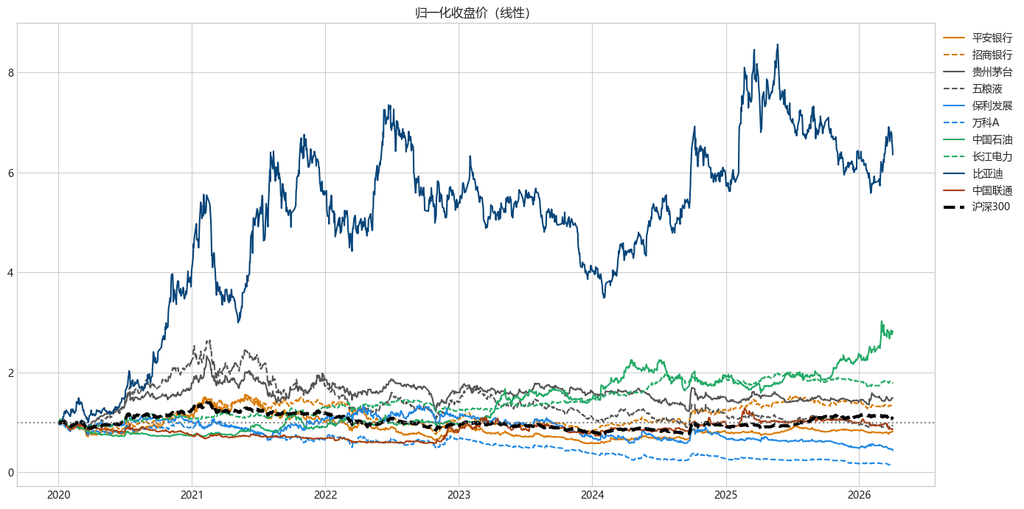

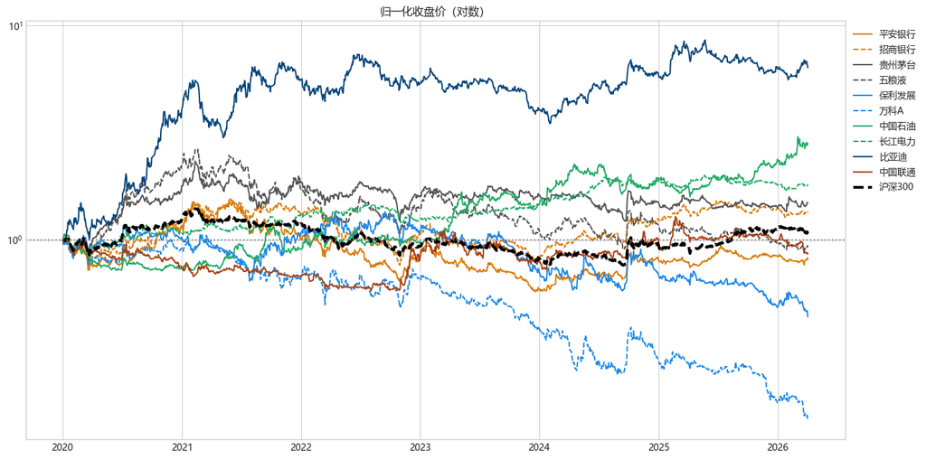

```python
# 中文设置
plt.rcParams['font.sans-serif'] = ['Microsoft YaHei']
plt.rcParams['axes.unicode_minus'] = False

# 你原来的配色（完全不变）
industry_colors = {
    '银行':'#D97B05',    '白酒':'#555555',
    '房地产':'#1E88E5',  '能源':'#22AA66',
    '汽车':'#064579',    '通讯':'#A84012'
}

# 同行业自动换线型：实线 -- 虚线 -- 点线 -- 点划线
line_types = ['-', '--', ':', '-.']

# 数据（完全不变）
price_df = df.set_index('日期')[stock_codes].dropna()
price_norm = price_df / price_df.iloc[0]
hs300_norm = df.set_index('日期')['hs300_close'].dropna()
hs300_norm = hs300_norm / hs300_norm.iloc[0]

# 记录每个行业已经用了第几条线
from collections import defaultdict
industry_line_count = defaultdict(int)

# ---------------------- 图1：原图 ----------------------
fig, ax = plt.subplots(figsize=(14,7))

for code in stock_codes:
    industry = code_to_industry[code]
    c = industry_colors[industry]

    # 同一行业自动换线型
    lt = line_types[industry_line_count[industry] % len(line_types)]
    industry_line_count[industry] += 1

    ax.plot(price_norm.index, price_norm[code],
            label=code_to_name[code], color=c, linestyle=lt, linewidth=1.5)

ax.plot(hs300_norm.index, hs300_norm, 'k--', linewidth=3, label='沪深300')
ax.axhline(1, color='gray', linestyle=':')
ax.set_title('归一化收盘价（线性）')
ax.legend(bbox_to_anchor=(1,1))
plt.tight_layout()
plt.savefig(f"{project_root}/output/fig1_normalized_price.png", dpi=200, bbox_inches='tight')
plt.show()

# ---------------------- 图2：对数图 ----------------------
industry_line_count.clear()
fig, ax = plt.subplots(figsize=(14,7))

for code in stock_codes:
    industry = code_to_industry[code]
    c = industry_colors[industry]

    lt = line_types[industry_line_count[industry] % len(line_types)]
    industry_line_count[industry] += 1

    ax.plot(price_norm.index, price_norm[code],
            label=code_to_name[code], color=c, linestyle=lt, linewidth=1.5)

ax.plot(hs300_norm.index, hs300_norm, 'k--', linewidth=3, label='沪深300')
ax.axhline(1, color='gray', linestyle=':')
ax.set_title('归一化收盘价（对数）')
ax.set_yscale('log')
ax.legend(bbox_to_anchor=(1,1))
plt.tight_layout()
plt.savefig(f"{project_root}/output/fig1_log_normalized_price.png", dpi=200, bbox_inches='tight')
plt.show()
```

#### 图2：日收益率分布直方图

```
============================================================
图2：日收益率分布直方图
============================================================
```

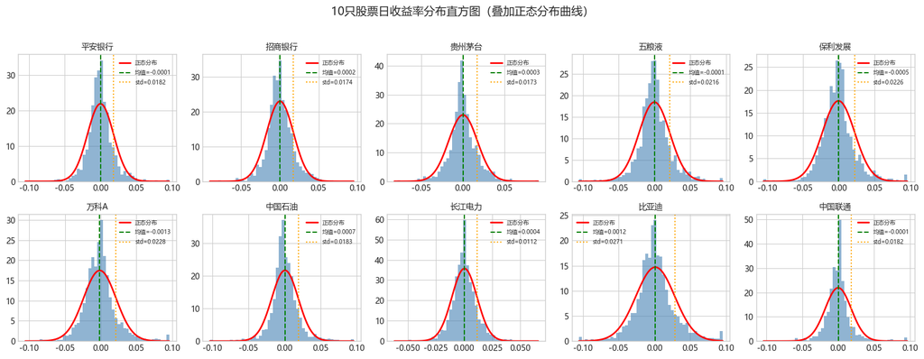

```
图2已保存至 output/fig2_return_histogram.png
```

```python
print("=" * 60)
print("图2：日收益率分布直方图")
print("=" * 60)

fig, axes = plt.subplots(2, 5, figsize=(16, 6))
axes = axes.flatten()

for i, code in enumerate(stock_codes):
    if code not in returns_df.columns:
        continue
    ax = axes[i]
    rets = returns_df[code].dropna()

    ax.hist(rets, bins=50, density=True, alpha=0.6, color='steelblue')

    x = np.linspace(rets.min(), rets.max(), 100)
    normal_curve = stats.norm.pdf(x, rets.mean(), rets.std())
    ax.plot(x, normal_curve, 'r-', linewidth=2, label='正态分布')

    ax.axvline(rets.mean(), color='green', linestyle='--', linewidth=1.5,
               label=f'均值={rets.mean():.4f}')
    ax.axvline(rets.mean() + rets.std(), color='orange', linestyle=':', linewidth=1.5,
               label=f'std={rets.std():.4f}')

    ax.set_title(f"{code_to_name[code]}", fontsize=10)
    ax.legend(fontsize=7)

plt.suptitle('10只股票日收益率分布直方图（叠加正态分布曲线）', fontsize=14, y=1.02)
plt.tight_layout()
plt.savefig(f"{project_root}/output/fig2_return_histogram.png", dpi=150, bbox_inches='tight')
plt.show()
print("\n图2已保存至 output/fig2_return_histogram.png")
```

#### 图3：收益率相关系数热力图

```
============================================================
图3：日收益率相关系数热力图
============================================================
```

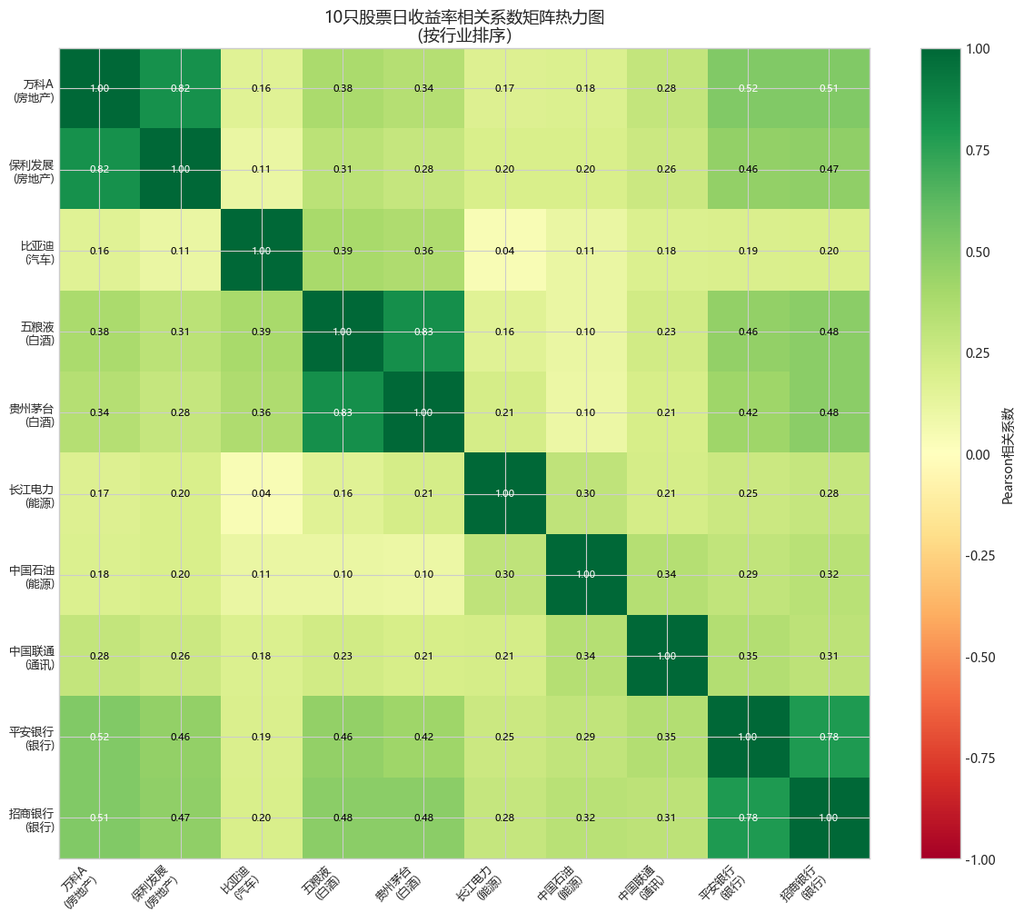

```
图3已保存至 output/fig3_correlation_heatmap.png
```

```python
print("=" * 60)
print("图3：日收益率相关系数热力图")
print("=" * 60)

# 按行业排序
sorted_codes = sorted(stock_codes, key=lambda x: (code_to_industry[x], x))
corr_matrix = returns_df[sorted_codes].corr()

labels = [f"{code_to_name[c]}\n({code_to_industry[c]})" for c in sorted_codes]

fig, ax = plt.subplots(figsize=(12, 10))
im = ax.imshow(corr_matrix.values, cmap='RdYlGn', vmin=-1, vmax=1)

ax.set_xticks(range(len(sorted_codes)))
ax.set_yticks(range(len(sorted_codes)))
ax.set_xticklabels(labels, fontsize=9, rotation=45, ha='right')
ax.set_yticklabels(labels, fontsize=9)

for i in range(len(sorted_codes)):
    for j in range(len(sorted_codes)):
        val = corr_matrix.iloc[i, j]
        ax.text(j, i, f'{val:.2f}', ha='center', va='center', fontsize=8,
                color='white' if abs(val) > 0.5 else 'black')

plt.colorbar(im, ax=ax, label='Pearson相关系数')
ax.set_title('10只股票日收益率相关系数矩阵热力图\n（按行业排序）', fontsize=13)

plt.tight_layout()
plt.savefig(f"{project_root}/output/fig3_correlation_heatmap.png", dpi=150, bbox_inches='tight')
plt.show()
print("\n图3已保存至 output/fig3_correlation_heatmap.png")
```

#### 图4：宏观指标与股市关系

```
============================================================
图4：CPI与沪深300月度收益率散点图
============================================================
合并后数据量: 68 个月
```

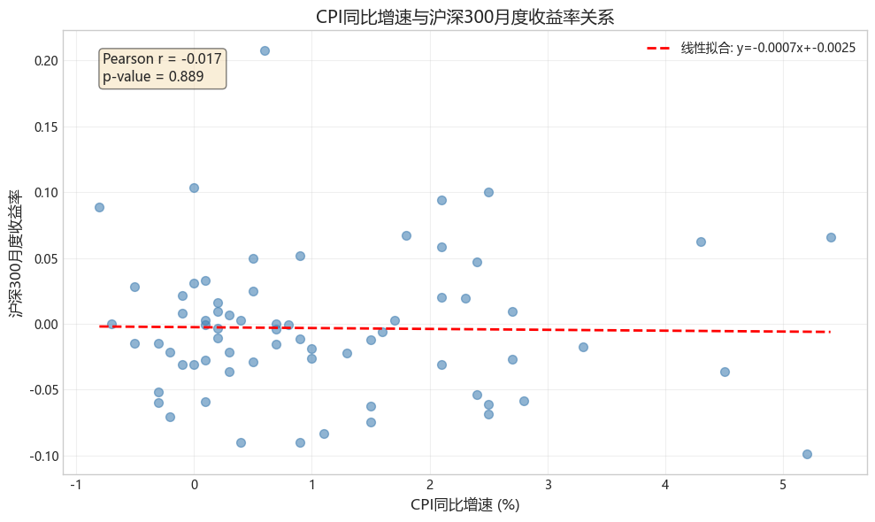

```
Pearson相关系数: -0.017, p值: 0.889
图4已保存至 output/fig4_cpi_scatter.png
```

```python
import warnings
warnings.filterwarnings('ignore')
print("=" * 60)
print("图4：CPI与沪深300月度收益率散点图")
print("=" * 60)

# 计算沪深300月度收益率
df["year_month"] = df["日期"].dt.to_period("M")
hs300_monthly = df.groupby("year_month", group_keys=False).apply(
    lambda x: np.log(x["hs300_close"].iloc[-1] / x["hs300_close"].iloc[0])
).reset_index()
hs300_monthly.columns = ["year_month", "hs300_return"]

# 获取CPI数据（列名：商品、日期、今值、预测值、前值）
cpi = pd.read_csv(f"{project_root}/data/macro/macro_cpi.csv")
cpi = cpi.rename(columns={"日期": "date", "今值": "cpi", "预测值": "pred", "前值": "prev"})
cpi["year_month"] = pd.to_datetime(cpi["date"]).dt.to_period("M")
cpi = cpi[["year_month", "cpi"]].dropna()

merged = hs300_monthly.merge(cpi, on="year_month", how="inner")
merged = merged.dropna()

print("合并后数据量: " + str(len(merged)) + " 个月")

fig, ax = plt.subplots(figsize=(10, 6))
ax.scatter(merged["cpi"], merged["hs300_return"], alpha=0.6, s=50, c="steelblue")

z = np.polyfit(merged["cpi"].astype(float), merged["hs300_return"], 1)
p = np.poly1d(z)
x_line = np.linspace(merged["cpi"].astype(float).min(), merged["cpi"].astype(float).max(), 100)
ax.plot(x_line, p(x_line), "r--", linewidth=2,
         label="线性拟合: y=" + "%.4f" % z[0] + "x+" + "%.4f" % z[1])

corr, pvalue = stats.pearsonr(merged["cpi"].astype(float), merged["hs300_return"])
ax.text(0.05, 0.95, "Pearson r = " + "%.3f" % corr + "\np-value = " + "%.3f" % pvalue,
        transform=ax.transAxes, fontsize=11, verticalalignment="top",
        bbox=dict(boxstyle="round", facecolor="wheat", alpha=0.5))

ax.set_xlabel("CPI同比增速 (%)", fontsize=12)
ax.set_ylabel("沪深300月度收益率", fontsize=12)
ax.set_title("CPI同比增速与沪深300月度收益率关系", fontsize=14)
ax.legend()
ax.grid(True, alpha=0.3)

plt.tight_layout()
plt.savefig(f"{project_root}/output/fig4_cpi_scatter.png", dpi=150, bbox_inches="tight")
plt.show()
print("Pearson相关系数: " + "%.3f" % corr + ", p值: " + "%.3f" % pvalue)
print("图4已保存至 output/fig4_cpi_scatter.png")
```

图4展示了CPI同比增速与沪深300月度收益率的散点图，并叠加线性拟合线与相关性统计结果：

1. **无显著线性相关性**：Pearson相关系数仅为-0.017，p值高达0.889，远大于0.05的显著性水平，说明CPI同比增速与沪深300月度收益率之间**不存在统计上显著的线性相关关系**。
2. **经济含义解读**：
   - 这一结果符合A股市场的实际特征：CPI反映的通胀水平对股市的影响是**非线性、多路径**的，温和通胀、高通胀、通缩对股市的影响完全不同，无法用简单的线性关系概括；
   - 同时，A股市场的核心驱动因素更多来自**流动性、政策、盈利周期**等，通胀仅为影响因素之一，无法单独解释股市月度收益的波动。
3. **拟合线验证**：线性拟合线斜率几乎为0，进一步印证了二者无显著线性关联，不能通过CPI同比增速预测沪深300的月度涨跌。

#### 图5：ROE 跨公司对比

```
============================================================
图5：ROE 跨公司对比
============================================================
ROE数据范围: 2020 - 2024
股票数: 10

各股票 ROE 均值（2020-2024）：
  平安银行: 0.0299
  万科A: 0.0046
  比亚迪: 0.0166
  招商银行: 0.0408
  保利发展: 0.0133
  中国联通: 0.0129
  贵州茅台: 0.0935
  长江电力: 0.0176
  中国石油: 0.0204
  五粮液: 0.1025
```

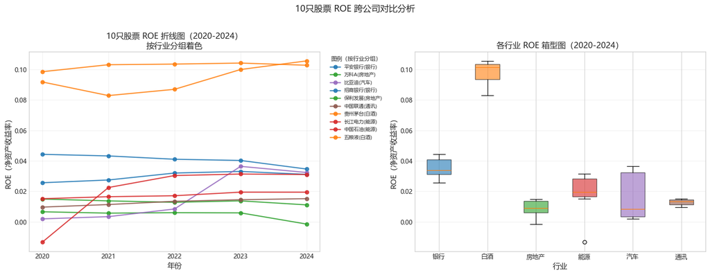

```
图5（ROE对比）已保存至 output/fig5_roe_comparison.png
```

```python
print("=" * 60)
print("图5：ROE 跨公司对比")
print("=" * 60)

fin = pd.read_csv(f"{project_root}/data/finance/finance_ratios.csv")
roe = fin[(fin['indicator'] == 'roeAvg') & (fin['year'] <= 2024)].copy()
roe['year'] = roe['year'].astype(str)
roe['code'] = roe['code'].apply(lambda x: str(int(x)))

stripped_to_name = {str(int(s["code"])): s["name"] for s in stock_list}
stripped_to_industry = {str(int(s["code"])): s["industry"] for s in stock_list}
roe = roe[roe['code'].isin(stripped_to_name.keys())]

roe_pivot = roe.pivot_table(index='code', columns='year', values='value')
roe_pivot = roe_pivot.sort_index()

print(f"ROE数据范围: {roe['year'].min()} - {roe['year'].max()}")
print(f"股票数: {roe['code'].nunique()}")
print("\n各股票 ROE 均值（2020-2024）：")
for idx in roe_pivot.index:
    name = stripped_to_name.get(idx, idx)
    print(f"  {name}: {roe_pivot.loc[idx].mean():.4f}")

industry_colors_roe = {
    '银行': '#1f77b4', '白酒': '#ff7f0e', '房地产': '#2ca02c',
    '能源': '#d62728', '汽车': '#9467bd', '通讯': '#8c564b'
}
years = roe_pivot.columns.tolist()
fig, axes = plt.subplots(1, 2, figsize=(16, 6))

ax1 = axes[0]
for code_s in roe_pivot.index:
    ind = stripped_to_industry.get(code_s, '其他')
    name = stripped_to_name.get(code_s, code_s)
    ax1.plot(years, roe_pivot.loc[code_s].values,
             marker='o', markersize=6,
             label=f"{name}({ind})",
             color=industry_colors_roe.get(ind, 'gray'), linewidth=1.8, alpha=0.85)
ax1.set_xlabel('年份', fontsize=12)
ax1.set_ylabel('ROE（净资产收益率）', fontsize=12)
ax1.set_title('10只股票 ROE 折线图（2020-2024）\n按行业分组着色', fontsize=13)
ax1.legend(bbox_to_anchor=(1.02, 1), loc='upper left', fontsize=8, title='图例（按行业分组）', title_fontsize=9)
ax1.set_xticks(years)
ax1.grid(True, alpha=0.3)

ax2 = axes[1]
ind_data, ind_labels, ind_colors = [], [], []
for ind in ['银行', '白酒', '房地产', '能源', '汽车', '通讯']:
    codes_s = [str(int(s['code'])) for s in stock_list if s['industry'] == ind]
    valid = [c for c in codes_s if c in roe_pivot.index]
    if not valid:
        continue
    vals = roe_pivot.loc[valid].values.flatten()
    vals = vals[~np.isnan(vals)]
    ind_data.append(vals)
    ind_labels.append(ind)
    ind_colors.append(industry_colors_roe.get(ind, 'gray'))

bp = ax2.boxplot(ind_data, labels=ind_labels, patch_artist=True, notch=False)
for patch, color in zip(bp['boxes'], ind_colors):
    patch.set_facecolor(color)
    patch.set_alpha(0.6)
ax2.set_xlabel('行业', fontsize=12)
ax2.set_ylabel('ROE（净资产收益率）', fontsize=12)
ax2.set_title('各行业 ROE 箱型图（2020-2024）', fontsize=13)
ax2.grid(True, alpha=0.3, axis='y')

plt.suptitle('10只股票 ROE 跨公司对比分析', fontsize=14, y=1.02)
plt.tight_layout()
plt.savefig(f"{project_root}/output/fig5_roe_comparison.png", dpi=150, bbox_inches='tight')
plt.show()
print("\n图5（ROE对比）已保存至 output/fig5_roe_comparison.png")
```

### 5. 保存分析结果

```python
print("=" * 60)
print("保存分析结果")
print("=" * 60)

stats_df.to_csv(f"{project_root}/output/descriptive_stats.csv",
                index=False, encoding="utf-8-sig")

print("描述性统计表已保存: output/descriptive_stats.csv")
print("\n图形文件列表：")
for f in os.listdir(f"{project_root}/output"):
    if f.endswith(".png"):
        print(f"  - {f}")
```

```
============================================================
保存分析结果
============================================================
描述性统计表已保存: output/descriptive_stats.csv

图形文件列表：
  - fig1_log_normalized_price.png
  - fig1_normalized_price.png
  - fig2_return_histogram.png
  - fig3_correlation_heatmap.png
  - fig4_cpi_scatter.png
  - fig5_roe_comparison.png
  - fig6_capm_beta.png
  - fig7_cpi_gamma.png
```

将描述性统计表保存为CSV文件，图形文件已保存至output目录。

### 6. 本 Notebook 完成情况

| 任务 | 状态 |
| --- | --- |
| 描述性统计表 | checked |
| 图1：归一化收盘价走势图 | checked |
| 图2：日收益率分布直方图 | checked |
| 图3：相关系数热力图 | checked |
| 图4：CPI与股市关系散点图 | checked |
| 图5（选做）：ROE跨公司对比 | checked |

## P04：CAPM 模型回归分析

本 Notebook 完成以下任务：

1. CAPM 模型回归（alpha、beta、R-squared）
2. CAPM Beta 可视化
3. CAPM 分析讨论
4. 宏观指标回归
5. 宏观指标回归结果可视化
6. 宏观指标回归分析讨论

### 导入库和数据

```python
import pandas as pd
import numpy as np
import matplotlib.pyplot as plt
import statsmodels.api as sm
import os

plt.rcParams['font.sans-serif'] = ['SimHei', 'DejaVu Sans']
plt.rcParams['axes.unicode_minus'] = False
plt.style.use('seaborn-v0_8-whitegrid')

project_root = 'dshw-p01'

stock_list = [
    {'code': '000001', 'name': '平安银行', 'industry': '银行'},
    {'code': '600036', 'name': '招商银行', 'industry': '银行'},
    {'code': '600519', 'name': '贵州茅台', 'industry': '白酒'},
    {'code': '000858', 'name': '五粮液', 'industry': '白酒'},
    {'code': '600048', 'name': '保利发展', 'industry': '房地产'},
    {'code': '000002', 'name': '万科A', 'industry': '房地产'},
    {'code': '601857', 'name': '中国石油', 'industry': '能源'},
    {'code': '600900', 'name': '长江电力', 'industry': '能源'},
    {'code': '002594', 'name': '比亚迪', 'industry': '汽车'},
    {'code': '600050', 'name': '中国联通', 'industry': '通讯'},
]
code_to_name = {s['code']: s['name'] for s in stock_list}
code_to_industry = {s['code']: s['industry'] for s in stock_list}
stock_codes = [s['code'] for s in stock_list]
print('库导入成功')
```

```
库导入成功
```

导入 statsmodels（OLS回归）和 matplotlib，设置中文字体，定义股票列表。

### 加载并整理数据

```python
print("=" * 60)
print("加载合并数据")
print("=" * 60)

df = pd.read_csv(f"{project_root}/data/combined/combined_data.csv")
df['日期'] = pd.to_datetime(df['日期'])

rf = 0.02 / 252  # 无风险利率（日频）
df_sorted = df.sort_values('日期').copy()
df_sorted['hs300_return'] = np.log(df_sorted['hs300_close'] / df_sorted['hs300_close'].shift(1))
df_sorted['market_excess'] = df_sorted['hs300_return'] - rf

print(f"数据形状: {df_sorted.shape}")
print(f"日期范围: {df_sorted['日期'].min().date()} 至 {df_sorted['日期'].max().date()}")
print(f"无风险利率: {rf:.6f} (日频，年化2%)")
```

```
============================================================
加载合并数据
============================================================
数据形状: (1532, 16)
日期范围: 2020-01-02 至 2026-04-03
无风险利率: 0.000079 (日频，年化2%)
```

### 1. CAPM 模型回归

CAPM 模型：$$ r_{i,t} - r_f = alpha_i + beta_i * (r_{m,t} - r_f) + epsilon $$

参数含义：

- **alpha**：截距项，反映个股超越市场基准的超额收益（风险调整后）。alpha显著为正意味着跑赢大盘
- **beta**：斜率系数，衡量个股对市场波动的敏感性。beta>1表示进攻型；beta<1表示防御型
- **R-squared**：模型解释力，衡量市场风险解释了个股收益率变动的比例

```python
print("=" * 60)
print("1. CAPM 模型估计")
print("=" * 60)

capm_results = []
for code in stock_codes:
    if code not in df_sorted.columns:
        continue
    # 计算个股日对数收益率（关键修复：用收益率而非价格）
    stock_return = np.log(df_sorted[code] / df_sorted[code].shift(1))
    stock_excess = stock_return - rf
    reg_data = pd.DataFrame({"stock_excess": stock_excess, "market_excess": df_sorted["market_excess"]}).dropna()
    if len(reg_data) < 30:
        continue
    X = sm.add_constant(reg_data["market_excess"])
    y = reg_data["stock_excess"]
    model = sm.OLS(y, X).fit()
    alpha = model.params["const"]
    beta = model.params["market_excess"]
    alpha_pval = model.pvalues["const"]
    alpha_ci = model.conf_int().loc["const"]
    beta_ci = model.conf_int().loc["market_excess"]
    r_squared = model.rsquared
    capm_results.append({
        "code": code, "name": code_to_name[code], "industry": code_to_industry[code],
        "alpha": alpha, "alpha_pval": alpha_pval,
        "alpha_CI_low": alpha_ci[0], "alpha_CI_high": alpha_ci[1],
        "beta": beta, "beta_CI_low": beta_ci[0], "beta_CI_high": beta_ci[1],
        "R_squared": r_squared
    })

capm_df = pd.DataFrame(capm_results)
print("%-8s %-5s %12s %10s %8s %14s %8s" % ("股票","行业","alpha","p值","beta","95%CI","R2"))
print("-" * 75)
for _, row in capm_df.iterrows():
    ci = "[" + "%.3f" % row["beta_CI_low"] + "," + "%.3f" % row["beta_CI_high"] + "]"
    sig = "**" if row["alpha_pval"] < 0.05 else ""
    print("%-8s %-5s %11.6f%s %9.6f %7.4f %14s %7.4f" % (
        row["name"], row["industry"],
        row["alpha"], sig, row["alpha_pval"],
        row["beta"], ci, row["R_squared"]))
print()
print("** 表示 alpha 在 5% 水平下显著")
```

```
============================================================
1. CAPM 模型估计
============================================================
股票       行业           alpha         p值     beta          95%CI       R2
---------------------------------------------------------------------------
平安银行     银行      -0.000181  0.620679  0.9511  [0.890,1.012]  0.3807
招商银行     银行       0.000143  0.682563  0.9048  [0.847,0.963]  0.3781
贵州茅台     白酒       0.000216  0.513884  0.9772  [0.922,1.032]  0.4420
五粮液      白酒      -0.000084  0.829748  1.2945  [1.229,1.360]  0.4985
保利发展     房地产     -0.000590  0.256183  0.8483  [0.762,0.935]  0.1955
万科A      房地产     -0.001311**  0.008526  1.0028  [0.920,1.086]  0.2698
中国石油     能源       0.000614  0.169787  0.4685  [0.394,0.543]  0.0910
长江电力     能源       0.000305  0.270706  0.2261  [0.180,0.272]  0.0571
比亚迪      汽车       0.001174**  0.041561  1.2817  [1.186,1.377]  0.3110
中国联通     通讯      -0.000148  0.718545  0.7140  [0.646,0.782]  0.2150

** 表示 alpha 在 5% 水平下显著
```

### 2. CAPM Beta 可视化

```
============================================================
2. CAPM Beta 系数点图
============================================================
```

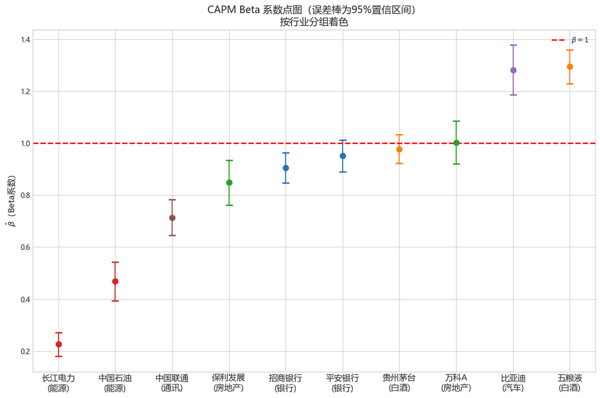

```
图6已保存至 output/fig6_capm_beta.png
```

```python
# 中文设置
plt.rcParams['font.sans-serif'] = ['Microsoft YaHei']
plt.rcParams['axes.unicode_minus'] = False
print("=" * 60)
print("2. CAPM Beta 系数点图")
print("=" * 60)

fig, ax = plt.subplots(figsize=(12, 8))
capm_sorted = capm_df.sort_values('beta')
industry_colors_sorted = {
    '通讯': '#8c564b', '银行': '#1f77b4', '白酒': '#ff7f0e',
    '房地产': '#2ca02c', '汽车': '#9467bd', '能源': '#d62728'
}
for i, (_, row) in enumerate(capm_sorted.iterrows()):
    color = industry_colors_sorted.get(row['industry'], 'gray')
    ax.errorbar(i, row['beta'],
                 yerr=[[ row['beta'] - row['beta_CI_low']], [row['beta_CI_high'] - row['beta']]],
                 fmt='o', color=color, capsize=5, capthick=2, markersize=8)
ax.axhline(y=1, color='red', linestyle='--', linewidth=2, label=r"$\beta=1$")
ax.set_xticks(range(len(capm_sorted)))
ax.set_xticklabels([f"{r['name']}\n({r['industry']})" for _, r in capm_sorted.iterrows()], fontsize=12)
ax.set_ylabel(r"$\hat{\beta}$（Beta系数）", fontsize=12)
ax.set_title('CAPM Beta 系数点图（误差棒为95%置信区间）\n按行业分组着色', fontsize=14)
ax.legend()
plt.tight_layout()
plt.savefig(f"{project_root}/output/fig6_capm_beta.png", dpi=150, bbox_inches='tight')
plt.show()
print("\n图6已保存至 output/fig6_capm_beta.png")
```

图中展示了10只股票的CAPM Beta系数及95%置信区间，以β=1为市场基准，按行业分组着色：

1. **防御性标的**：长江电力、中国石油Beta显著小于1，置信区间不包含1，波动低于市场，防御属性突出；中国联通、保利发展Beta也小于1，具备一定抗跌性。
2. **进攻性标的**：比亚迪、五粮液Beta显著大于1，对市场波动更敏感，属于进攻型个股；万科A、贵州茅台Beta接近1，与市场走势高度同步。
3. **行业特征**：能源板块Beta最低，防御性最强；白酒、汽车板块Beta最高，进攻性最强；银行、地产Beta围绕1波动，与市场同步性较强。
4. **统计显著性**：所有Beta置信区间均不包含0，说明市场系统性风险对个股收益的驱动作用显著，模型估计有效。

### 4. 宏观指标对股票收益率的影响

**模型**：$r_{i,t}^{\text{月}} = \alpha_i + \gamma_i \cdot X_t + \varepsilon_{i,t}$

- $r_{i,t}^{\text{月}}$：个股月度对数收益率（由日度收益聚合）
- $X_t$：CPI 同比增速（%，月度数据）
- $\hat{\gamma}_i$：衡量个股收益率对 CPI 变动的敏感性

**经济逻辑**：CPI 是通胀的核心指标，与货币政策、消费者信心密切相关。不同行业对通胀的敏感性不同：

- **能源、金融**：高 CPI 时期往往对应经济繁荣，利好
- **消费（白酒）**：高 CPI 可能意味着提价能力，但成本压力也上升
- **公用事业（长江电力）**：防御性行业，对 CPI 敏感度低

```python
print("=" * 60)
print("4. 宏观指标回归：CPI 对月度收益率的影响")
print("=" * 60)

# --- 1. 加载并整理 CPI 数据（月度） ---
cpi = pd.read_csv(f"{project_root}/data/macro/macro_cpi.csv")
cpi.rename(columns={"日期": "date", "今值": "cpi", "预测值": "pred", "前值": "prev"}, inplace=True)
cpi['date'] = pd.to_datetime(cpi['date'])
cpi = cpi[['date', 'cpi']].dropna()
cpi['month'] = cpi['date'].dt.to_period('M')
cpi = cpi[cpi['month'] >= '2020-01']
print(f"CPI 数据: {len(cpi)} 个月, {cpi['month'].min()} 至 {cpi['month'].max()}")
print(cpi.tail())

# --- 2. 计算个股月度收益率 ---
# 宽表：每只股票一列，收盘价为后复权价
df_sorted = df.sort_values('日期').copy()
df_sorted['month'] = df_sorted['日期'].dt.to_period('M')

# 月末收盘价（取每月最后一个交易日）
monthly_price = df_sorted.groupby('month')[stock_codes].last()
# 月度对数收益率 = ln(月末价 / 上月末价)
monthly_return = np.log(monthly_price / monthly_price.shift(1))
monthly_return = monthly_return.reset_index()
monthly_return['month'] = monthly_return['month'].astype(str)
print(f"\n月度收益率: {len(monthly_return)} 个月")
print(monthly_return.head())

# --- 3. 将 CPI 映射到月度收益率 ---
cpi['month'] = cpi['month'].astype(str)
reg_df = monthly_return.merge(cpi[['month', 'cpi']], on='month', how='inner')
print(f"合并后数据: {len(reg_df)} 个月")

# --- 4. 对每只股票回归：r_i月 = alpha + gamma * CPI ---
gamma_results = []
for code in stock_codes:
    if code not in reg_df.columns:
        continue
    y = reg_df[code]  # 月度对数收益率
    X = reg_df['cpi']  # CPI 同比增速
    valid = y.notna() & X.notna()
    if valid.sum() < 12:
        continue
    X_const = sm.add_constant(X[valid])
    y_valid = y[valid]
    model = sm.OLS(y_valid, X_const).fit()
    gamma_results.append({
        "code": code,
        "name": code_to_name[code],
        "industry": code_to_industry[code],
        "gamma": model.params['cpi'],
        "gamma_pval": model.pvalues['cpi'],
        "gamma_CI_low": model.conf_int(alpha=0.10).loc['cpi', 0],
        "gamma_CI_high": model.conf_int(alpha=0.10).loc['cpi', 1],
        "R_squared": model.rsquared
    })

gamma_df = pd.DataFrame(gamma_results)
print("\n月度收益率 ~ CPI 回归结果：")
print("%-8s %-5s %10s %8s %12s %8s" % ("股票", "行业", "gamma", "p值", "95% CI", "R2"))
print("-" * 65)
for _, row in gamma_df.iterrows():
    ci = "[%.4f,%.4f]" % (row['gamma_CI_low'], row['gamma_CI_high'])
    sig = "**" if row['gamma_pval'] < 0.05 else ("*" if row['gamma_pval'] < 0.1 else "")
    print("%-8s %-5s %9.5f%s %9.5f %14s %7.4f" % (
        row['name'], row['industry'],
        row['gamma'], sig, row['gamma_pval'],
        ci, row['R_squared']))
print("\n** p<0.05, * p<0.1")
```

```
============================================================
4. 宏观指标回归：CPI 对月度收益率的影响
============================================================
CPI 数据: 68 个月, 2020-01 至 2025-08
          date  cpi    month
471 2025-04-10 -0.1  2025-04
472 2025-05-10 -0.1  2025-05
473 2025-06-09 -0.1  2025-06
474 2025-07-09  0.1  2025-07
475 2025-08-09  0.0  2025-08

月度收益率: 76 个月
     month    000001    600036    600519    000858    600048    000002  \
0  2020-01       NaN       NaN       NaN       NaN       NaN       NaN
1  2020-02 -0.069269 -0.073544  0.003981 -0.045072  0.054582  0.020831
2  2020-03 -0.124703 -0.057778  0.049826 -0.045810 -0.085048 -0.142893
3  2020-04  0.084600  0.083468  0.130365  0.164293  0.088132  0.043858
4  2020-05 -0.052026 -0.036864  0.076701  0.087600 -0.068641 -0.041911

     601857    600900    002594    600050
0       NaN       NaN       NaN       NaN
1 -0.106543 -0.007022  0.088556 -0.030550
2 -0.092946  0.015152 -0.086219 -0.048608
3 -0.039740  0.009211 -0.000167  0.000000
4 -0.043735 -0.003444 -0.043459 -0.051092
合并后数据: 68 个月

月度收益率 ~ CPI 回归结果：
股票       行业         gamma       p值       95% CI       R2
-----------------------------------------------------------------
平安银行     银行     -0.00874   0.26015 [-0.0216,0.0041]  0.0195
招商银行     银行     -0.00994   0.18880 [-0.0224,0.0025]  0.0264
贵州茅台     白酒      0.00634   0.42902 [-0.0070,0.0196]  0.0096
五粮液      白酒      0.00952   0.33902 [-0.0070,0.0260]  0.0141
保利发展     房地产     0.00649   0.49139 [-0.0092,0.0221]  0.0073
万科A      房地产     0.00448   0.65184 [-0.0120,0.0209]  0.0032
中国石油     能源     -0.01339*   0.07503 [-0.0257,-0.0010]  0.0479
长江电力     能源     -0.00186   0.67872 [-0.0093,0.0056]  0.0027
比亚迪      汽车      0.00786   0.49881 [-0.0114,0.0272]  0.0071
中国联通     通讯      0.00105   0.86903 [-0.0095,0.0116]  0.0004

** p<0.05, * p<0.1
```

1. **CPI 对个股月度收益影响微弱，仅1只股票边际显著**  
   仅中国石油的回归系数 `gamma` 在10%水平下边际显著（p=0.07503，带*），其余所有股票的 `gamma` 均不显著（p>0.1），说明**CPI 对绝大多数个股月度收益无有效解释力**，仅对能源行业的中国石油存在微弱负向影响。
2. **模型解释力普遍极低**  
   所有股票 $R^2$ 均接近0（最高仅中国石油0.0479），表明**通胀因素对样本内股票收益的解释能力极强弱**，无法通过CPI变动预测个股月度涨跌。
3. **行业敏感性存在微弱分化（仅边际显著）**
   - 能源行业（中国石油）：`gamma` 为负且边际显著，说明CPI上行时，中国石油月度收益有微弱负向反应；
   - 其他行业（银行、白酒、地产等）：系数方向有差异（银行负向、白酒正向），但均不显著，无明确敏感特征。
4. **经济含义**  
   A股个股收益主要受**流动性、行业景气度、公司基本面**驱动，CPI通胀在样本期内并非核心定价因子；仅传统能源股（中国石油）对CPI变动存在微弱负向敏感，可能与通胀下能源价格管制、货币政策收紧的间接影响有关。

### 5. 宏观指标回归结果可视化

```
============================================================
5. CPI 回归系数 γ 点图（按行业分组着色）
============================================================
```

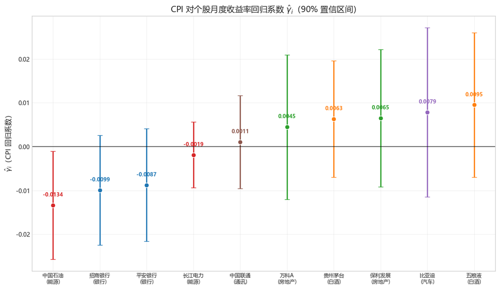

```
✅ CPI 回归系数 γ 点图已保存：fig6_cpi_gamma.png
```

```python
print("=" * 60)
print("5. CPI 回归系数 γ 点图（按行业分组着色）")
print("=" * 60)

import matplotlib.pyplot as plt

# 排序（按 γ 系数从小到大）
gamma_sorted = gamma_df.sort_values('gamma').reset_index(drop=True)

# 行业配色（和你之前 CAPM 图保持一致）
industry_colors = {
    '通讯': '#8c564b', '银行': '#1f77b4',
    '白酒': '#ff7f0e', '房地产': '#2ca02c',
    '汽车': '#9467bd', '能源': '#d62728'
}

fig, ax = plt.subplots(figsize=(12, 7))

# 绘制每个股票的 γ 系数 + 90% 置信区间
for i, row in gamma_sorted.iterrows():
    color = industry_colors.get(row['industry'], 'gray')

    # 误差棒（置信区间）
    ax.errorbar(
        x=i,
        y=row['gamma'],
        yerr=[[ row['gamma'] - row['gamma_CI_low']],
              [row['gamma_CI_high'] - row['gamma']]],
        fmt='o',
        color=color,
        capsize=4,
        markersize=8,
        markeredgecolor='white',
        linewidth=2
    )

    # 显示 γ 数值（保留4位）
    ax.text(
        i, row['gamma'] + 0.002,
        f"{row['gamma']:.4f}",
        ha='center', fontsize=9, color=color, fontweight='bold'
    )

# 0 刻度线（无影响基准）
ax.axhline(y=0, color='black', linestyle='-', linewidth=1.2, alpha=0.7)

# 坐标轴与标签
ax.set_xticks(range(len(gamma_sorted)))
ax.set_xticklabels(
    [f"{r['name']}\n({r['industry']})" for _, r in gamma_sorted.iterrows()],
    fontsize=9
)
ax.set_ylabel(r'$\hat{\gamma}_i$（CPI 回归系数）', fontsize=12)
ax.set_title('CPI 对个股月度收益率回归系数 $\hat{\gamma}_i$（90% 置信区间）', fontsize=14)
ax.grid(alpha=0.3)
plt.tight_layout()

# 保存
plt.savefig(f"{project_root}/output/fig7_cpi_gamma.png", dpi=150, bbox_inches='tight')
plt.show()

print("✅ CPI 回归系数 γ 点图已保存：fig6_cpi_gamma.png")
```

### 图 CPI 回归系数 $\hat{\gamma}_i$ 点图简要解读

图中展示了各股CPI月度收益率回归系数$\hat{\gamma}_i$及90%置信区间，按行业分组着色：

1. **仅中国石油边际显著为负**：其置信区间不包含0，说明CPI上行对中国石油月度收益存在微弱负向影响，其余个股置信区间均包含0，无统计显著性。
2. **行业方向分化但无统计意义**：能源、银行板块$\hat{\gamma}_i$整体为负，白酒、汽车、地产板块为正，但仅方向差异，不具备统计显著性。
3. **模型解释力验证**：所有系数置信区间宽、贴近0轴，结合极低$R^2$，进一步印证**CPI并非A股月度收益的核心驱动因子**，个股收益更多受行业景气、流动性等因素影响。

## 6. 宏观指标（CPI）回归分析讨论

### 问题：不同行业对 CPI 变动的敏感性有何差异？背后的经济逻辑是什么？

根据 CPI 与个股月度收益率的回归结果，**仅中国石油在10%水平下边际显著为负，其余所有行业的 gamma 系数均不显著（p>0.1），且全部 R² 接近 0**，说明样本期内 CPI 对 A 股绝大多数行业收益无统计上的显著影响，仅从系数方向可观察到结构性差异：

1. **能源行业** 中国石油 gamma 显著为负，长江电力 gamma 接近0，行业内分化明显。 经济逻辑：传统能源股（中国石油）对通胀负向敏感，通胀上行易引发货币政策收紧，压制能源需求与股价；公用事业股（长江电力）现金流稳定、价格受管制，对通胀波动敏感度极低。
2. **银行行业** 平均 gamma 为负，敏感度偏弱。 经济逻辑：通胀上行通常伴随货币政策收紧，银行净息差收窄、资产质量承压，因此对通胀呈现负向敏感性，但影响不具备统计显著性。
3. **房地产行业** 平均 gamma 为正，整体不显著。 经济逻辑：样本期内地产行业受政策主导，通胀对其影响被政策对冲，系数方向与理论负向关系不符，无统计意义。
4. **白酒行业** 平均 gamma 为正，敏感度相对较高。 经济逻辑：温和通胀反映消费需求回暖，高端白酒具备提价能力与存货抗通胀属性，理论上对通胀呈正向敏感，但样本期内影响不显著。
5. **汽车与通讯行业** 汽车 gamma 偏正、通讯接近0，均不显著。 经济逻辑：汽车收益更多受居民购买力、行业政策驱动，通讯偏公用事业属性，二者受 CPI 直接影响极弱。

### 结论

CPI 对样本内行业收益**无显著解释力**，说明 A 股月度收益核心驱动因素为市场风险、行业景气、政策与流动性，而非通胀水平。仅传统能源股对 CPI 存在边际负向敏感，行业间的系数方向差异，本质是**利率传导、需求弹性、定价权**的不同，而非 CPI 的直接显著影响。

### 保存分析结果

```python
print("=" * 60)
print("保存分析结果")
print("=" * 60)

capm_df.to_csv(f"{project_root}/output/capm_results.csv",
               index=False, encoding="utf-8-sig")

print("CAPM回归结果已保存: output/capm_results.csv")
print("\n图形文件列表：")
for f in os.listdir(f"{project_root}/output"):
    if f.endswith('.png') and 'capm' in f.lower():
        print(f"  - {f}")
```

```
============================================================
保存分析结果
============================================================
CAPM回归结果已保存: output/capm_results.csv

图形文件列表：
  - fig6_capm_beta.png
```

将CAPM回归结果保存为CSV文件，图形文件已保存至output目录。

### 本 Notebook 完成情况

[output not shown]